# Day 2: Heatmaps and small multiples

# Potentially useful libraries and starter code

```r
library(corrplot)
library(dplyr)
library(GGally) # to make pair plots
library(ggplot2)
library(pheatmap) # a cool heatmap library
library(RColorBrewer)
library(tidyr)
library(tidyverse)

# European Quality of Life Dataset
qol <- read.csv("../data/eqls_2007and2011_with_labels.csv")
# Cardiovascular data
cardio_train <- read.csv("../data/cardio_train.csv", sep=";")
```

# Exercise 1: Exploratory data analysis on a cardiovascular training dataset

Here is a brief summary of the dataset:

- age: in days
- height: in cm
- weight: in kg
- gender (should be referred as sex): 1 = woman, 2 = man
- cholesterol: 1 = normal, 2 = above normal, 3 = well above normal
- glucose: 1 = normal, 2 = above normal, 3 = well above normal
- alcohol intake: 0 = does not drink, 1 = drinks (self-reported)
- smoking: 0 = does not smoke cigarettes, 1 = smokes (self-reported)
- physical activity: 0 = < 1 hour of physical activity per day, 1 = >= 1 hours (self-reported)
- cardio: 0 = no cardiovascular disease, 1 = diagnosed with CV disease
1. Print all the column names in the dataset

```r
# Print the column headers
column_headers <- colnames(cardio_train)
print(column_headers)
```

```
##  [1] "id"          "age"         "gender"      "height"      "weight"
##  [6] "sys_bp"      "di_bp"       "cholesterol" "gluc"        "smoke"
## [11] "alco"        "active"      "cardio"
```

2. Add another column called age_yrs which has the ages in years (float values)

```r
# Convert age from days to years
cardio_train$age_yrs <- cardio_train$age / 365.25

head(cardio_train)
```

```
##   id   age gender height weight sys_bp di_bp cholesterol gluc smoke alco active
## 1  0 18393      2    168     62    110    80           1    1     0    0      1
## 2  1 20228      1    156     85    140    90           3    1     0    0      1
## 3  2 18857      1    165     64    130    70           3    1     0    0      0
## 4  3 17623      2    169     82    150   100           1    1     0    0      1
## 5  4 17474      1    156     56    100    60           1    1     0    0      0
## 6  8 21914      1    151     67    120    80           2    2     0    0      0
##   cardio  age_yrs
## 1      0 50.35729
## 2      1 55.38125
## 3      1 51.62765
## 4      1 48.24914
## 5      0 47.84120
## 6      0 59.99726
```

4. Do you see any null values? Are there any zeros in the age_yrs, gender*, height, weight, sys_bp, di_bp columns?

```r
# Filter NA values
cardio_train <- na.omit(cardio_train)

# Remove rows with abnormal zeros
cardio_train <- cardio_train %>%
  filter(age_yrs != 0, gender != 0, height != 0, weight != 0, sys_bp != 0, di_bp != 0)
```

5. Examine carefully the columns sys_bp, di_bp, weight, height, and age_yrs, cholesterol.

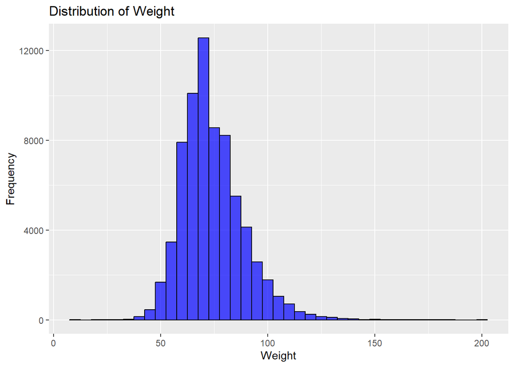

```r
#     Make a plot for each distribution.
# Create a histogram for the 'weight' column
ggplot(cardio_train, aes(x = weight)) +
  geom_histogram(binwidth = 5, fill = "blue", color = "black", alpha = 0.7) +
  labs(title = "Distribution of Weight",
       x = "Weight",
       y = "Frequency")
```

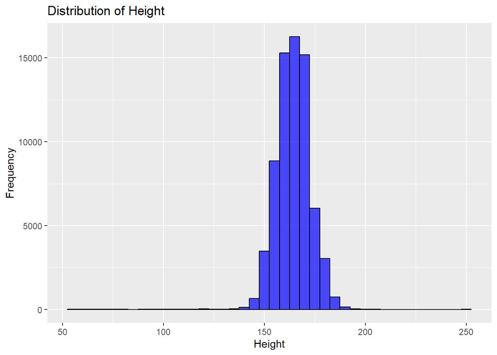

```r
# Create a histogram for the 'height' column
ggplot(cardio_train, aes(x = height)) +
  geom_histogram(binwidth = 5, fill = "blue", color = "black", alpha = 0.7) +
  labs(title = "Distribution of Height",
       x = "Height",
       y = "Frequency")
```

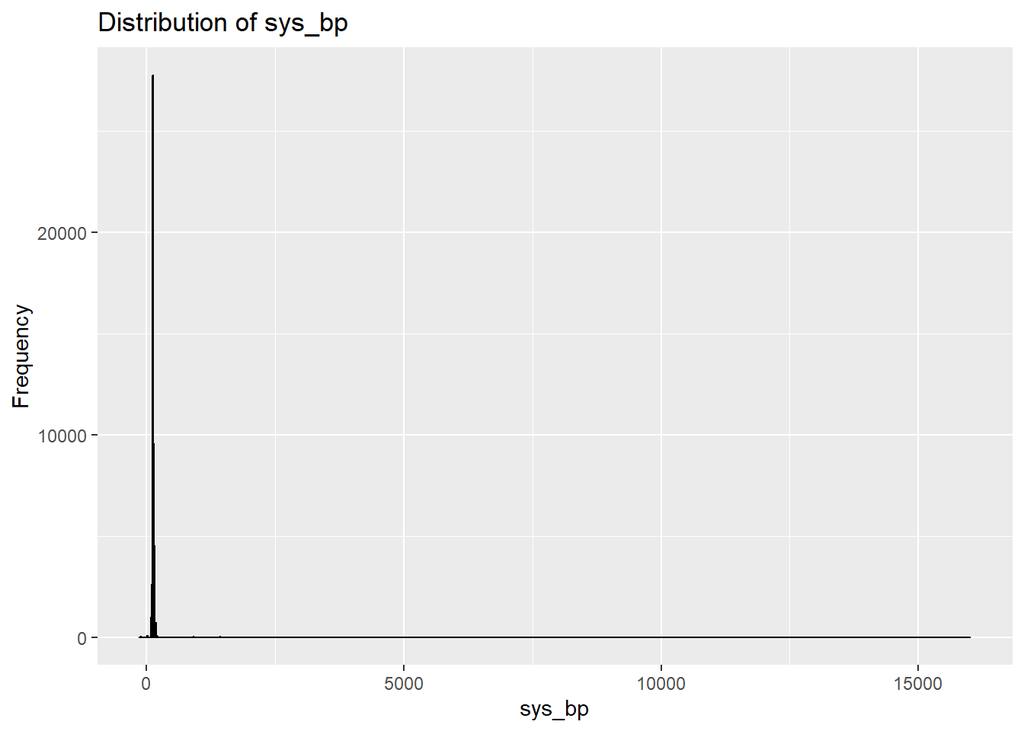

```r
# Create a histogram for the 'sys_bp' column
ggplot(cardio_train, aes(x = sys_bp)) +
  geom_histogram(binwidth = 5, fill = "blue", color = "black", alpha = 0.7) +
  labs(title = "Distribution of sys_bp",
       x = "sys_bp",
       y = "Frequency")
```

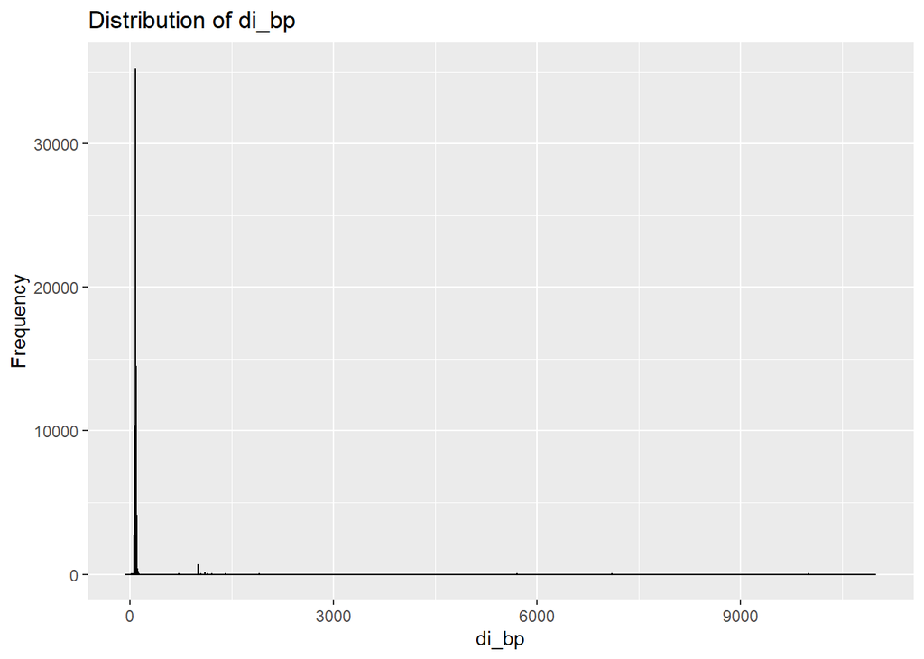

```r
# Create a histogram for the 'di_bp' column
ggplot(cardio_train, aes(x = di_bp)) +
  geom_histogram(binwidth = 5, fill = "blue", color = "black", alpha = 0.7) +
  labs(title = "Distribution of di_bp",
       x = "di_bp",
       y = "Frequency")
```

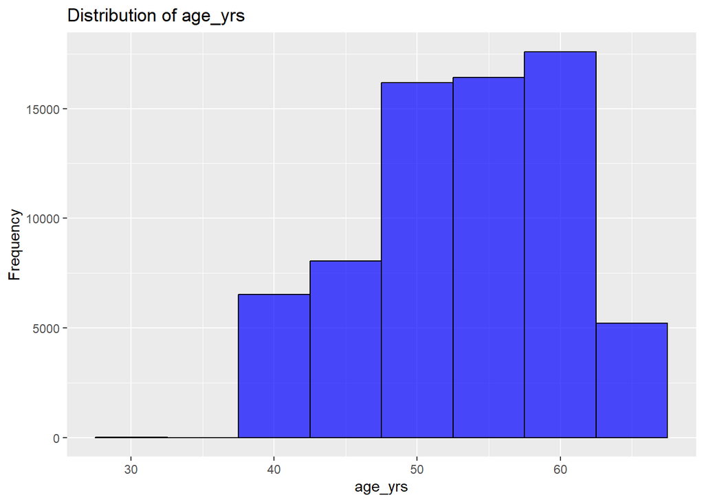

```r
# Create a histogram for the 'age_yrs' column
ggplot(cardio_train, aes(x = age_yrs)) +
  geom_histogram(binwidth = 5, fill = "blue", color = "black", alpha = 0.7) +
  labs(title = "Distribution of age_yrs",
       x = "age_yrs",
       y = "Frequency")
```